# Oplossingen examen

Jens Buysse

12/7/2020

## Oplossingen examen

### Opgave 1.1

- CRC Checksum:

| 1 | 0 | 0 | 0 | 0 | 1 | 0 | 1 | 1 | 0 |
| --- | --- | --- | --- | --- | --- | --- | --- | --- | --- |
| 1 | 0 | 1 | 1 | 1 |  |  |  |  |  |
| 0 | 0 | 1 | 1 | 1 | 1 | 0 | 1 | 1 | 0 |
|  |  | 1 | 0 | 1 | 1 | 1 |  |  |  |
|  |  | 0 | 1 | 0 | 0 | 1 | 1 | 1 | 0 |
|  |  |  | 1 | 0 | 1 | 1 | 1 |  |  |
|  |  |  | 0 | 0 | 1 | 0 | 0 | 1 | 0 |
|  |  |  |  |  | 1 | 0 | 1 | 1 | 1 |
|  |  |  |  |  | 0 | 0 | 1 | 0 | 1 |

De CRC checksum is dus 0101.

### Opgave 1.2

| 1 | 1 | 0 | 1 | 0 | 0 | 0 | 0 | 1 | 1 | 0 | 0 |
| --- | --- | --- | --- | --- | --- | --- | --- | --- | --- | --- | --- |
| 1 | 0 | 1 | 1 | 1 | 1 |  |  |  |  |  |  |
| 0 | 1 | 1 | 0 | 1 | 1 | 0 | 0 | 1 | 1 | 0 | 0 |
|  | 1 | 0 | 1 | 1 | 1 | 1 |  |  |  |  |  |
|  | 0 | 1 | 1 | 0 | 0 | 1 | 0 | 1 | 1 | 0 | 0 |
|  |  | 1 | 0 | 1 | 1 | 1 | 1 |  |  |  |  |
|  |  | 0 | 1 | 1 | 1 | 0 | 1 | 1 | 1 | 0 | 0 |
|  |  |  | 1 | 0 | 1 | 1 | 1 | 1 |  |  |  |
|  |  |  | 0 | 1 | 0 | 1 | 0 | 0 | 1 | 0 | 0 |
|  |  |  |  | 1 | 0 | 1 | 1 | 1 | 1 |  |  |
|  |  |  |  | 0 | 0 | 0 | 1 | 1 | 0 | 0 | 0 |

$1100 \neq 1011$ dus de reeks bevat bitfouten

### Opgave 1.3

|  | 1 | 1 | 1 | 1 | 1 | 1 | 1 | 1 | 1 | 1 | 1 |  |
| --- | --- | --- | --- | --- | --- | --- | --- | --- | --- | --- | --- | --- |
|  | 1 | 2 | 3 | 4 | 5 | 6 | 7 | 8 | 9 | 10 | 11 |  |
|  | p1 | p2 | d1 | p3 | d2 | d3 | d4 | p4 | d5 | d6 | d7 |  |
| p1 | 1 |  | 1 |  | 1 |  | 1 |  | 1 |  | 1 | 6 |
| p2 |  | 1 | 1 |  |  | 1 | 1 |  |  | 1 | 1 | 6 |
| p3 |  |  |  | 1 | 1 | 1 | 1 |  |  |  |  | 4 |
| p4 |  |  |  |  |  |  |  | 1 | 1 | 1 | 1 | 4 |

### Opgave 1.4

Zelf oplossen

### Opgave 2

- $(1011010,0111)_2$
  - Voor de komma : $64+16+8+2 = 90$ $(2^1 + 2^3 + ... + 2^6)$
  - Na de komma: $0.25 + 0.125 + 0.0625 = 0.4375$
  - Volledig dus: $(90.4375)_{10}$
- $(E15,03B)_{16}$
  - Voor de komma: $(1110.0001.0101)_2$
  - Na de komma: $(0000.0011.1011)_2$
  - Samen is dit: $(111 000 010 101,000 000 111 011)_2$
  - Samen is dit: $(7025,0073)_8$
- $(130,32)_{16}$
  - Binair: $(0001.0011.0000,0011.0010)_2$
  - Decimaal: $(16+32+256)=304$,$(0+0.125+0.0625+ 0.0078125)$ of dus 0.1953125
  - Samen: $(304,1953125)_{10}$
- $(739)_{10}$
  - $2 \times 256 = 512$
  - $739 - 512 = 227$
  - $256 / 16 = 14$
  - $14 \times 16 = 224$
  - $227-224 = 3$
  - $2\times 16^2 + 14\times 16^1 + 3 \times 16^0$
  - $(2E3)_{16}$

### Opgave 3

- $(-118)$ in 2-complement $01110110 \rightarrow 10001001 \rightarrow 10001010$
- $(-80)$ in 2-complement $01010000 \rightarrow 10101111 \rightarrow 10110000$

- | 1 | 1 | 0 | 0 | 0 | 1 | 0 | 1 | 0 |
  | --- | --- | --- | --- | --- | --- | --- | --- | --- |
  |  | 1 | 0 | 1 | 1 | 0 | 0 | 0 | 0 |
  |  | 0 | 0 | 1 | 1 | 1 | 0 | 1 | 0 |

Carry over naar buiten, dus overflow en foute berekening. Antwoord D.

### Opgave 4

- $(32B00000)_{16}$
- $(0011.0010.1011.0000.0000.0000.0000.0000)_2$ in IEEE binaire versie
  - Teken: 0, dus positief
  - Exponent: $(01100101)_{E2} = 64 + 32 + 4 + 1 = (101)_{10} \rightarrow 101-127 = -26$
  - Mantisseberekening: $(01100000000000000000000)$ Let op ! Impliciete 1 $\rightarrow (1,011)_2 \rightarrow (1,375)_{10}$
  - Samen dus $+1 2^{-26} \times 1,375$

### Opgave 5.1

- $2 + 2 + 1 = 5$
- $f(4) = 4 +1 = 5$
- $dom(f) = \mathbb{R}$
- $bld(g) = \mathbb{R_0^+}$

#### Nulpunten:

- f: -1
- g: /
- h: 0

#### Tekening

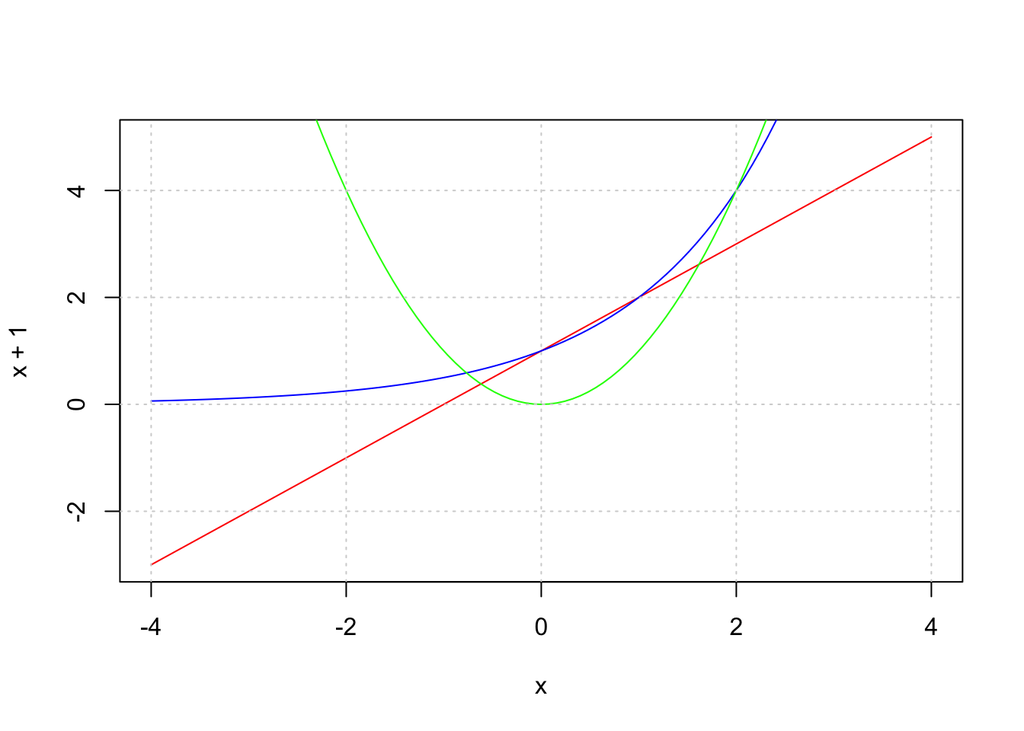

```r
curve(x+1,from = -4,to= 4, col="RED")
curve(2^x,from = -4,to= 4, add= TRUE, col="BLUE")
curve(x^2,from = -4,to= 4, add= TRUE, col="GREEN")
grid()
```

### Opgave 5

We noteren $x$ als 1 en $\overline{x}$ als 0, zelfde voor $y$ en $z$.

|  | 00 | 01 | 11 | 10 |
| --- | --- | --- | --- | --- |
| 0 | 1 | 0 | 0 | 0 |
| 1 | 1 | 1 | 1 | 1 |

### Opgave 6

$$\begin{eqnarray}
f(x,y,z) & = (x.y) + (y. (y + \overline{z})) + (\overline{y}.z) & (opgave) \\
& = (x.y) + (y.y + y.\overline{z}) + (\overline{y}.z)& (distributief)\\
& = (x.y) + (y + y.\overline{z}) + (\overline{y}.z)& (idempotentie)\\
& = (x.y) + (y) + (\overline{y}.z) & (absorptie)\\
& = x.y + y + \overline{y}.z & (associatief)\\
& = y + \overline{y}.z & (absorptie)\\
\end{eqnarray}$$

### Opgave 7

- Antwoord 1 is juist: $(A+B).C.D.E$

### Opgave 8

- Het aantal elementen in $\mathbb{Z}_{29}$: andere waarde, 29
- $31.30 - 2902 \equiv 2.1 - 2 \equiv 0 \mod{29}$
- $x \equiv 21 \mod{29}$
- $x \equiv 16 \mod{29}$

### Opgave 9

| p | q | $p \wedge q$ | $(p \wedge q) \vee q$ | $(p \wedge q) \vee q \rightarrow q$ |
| --- | --- | --- | --- | --- |
| 0 | 0 | 0 | 0 | 1 |
| 0 | 1 | 0 | 1 | 1 |
| 1 | 0 | 0 | 0 | 1 |
| 1 | 1 | 1 | 1 | 1 |

$((p \wedge q) \vee q )\rightarrow q$ is wel een tautologie en is geen contradictie.